# slide_deck_presentation

## Ford Gobike Data Exploration

This data set includes information about individual rides made in a bike-sharing system covering the greater San Francisco Bay area. Note that this dataset will require some data wrangling in order to make it tidy for analysis. There are multiple cities covered by the linked system, and multiple data files will need to be joined together if a full year’s coverage is desired.

```python
import numpy as np
import pandas as pd
import matplotlib.pyplot as plt
import seaborn as sb
import os
import glob

%matplotlib inline
```

```python
df = pd.read_csv('fordgobike-tripdata.csv')
df.head()
```

|  | duration_sec | start_time | end_time | start_station_id | start_station_name | start_station_latitude | start_station_longitude | end_station_id | end_station_name | end_station_latitude | end_station_longitude | bike_id | user_type | member_birth_year | member_gender | bike_share_for_all_trip |
| --- | --- | --- | --- | --- | --- | --- | --- | --- | --- | --- | --- | --- | --- | --- | --- | --- |
| 0 | 52185 | 32:10.1 | 01:56.0 | 21.0 | Montgomery St BART Station (Market St at 2nd St) | 37.789625 | -122.400811 | 13.0 | Commercial St at Montgomery St | 37.794231 | -122.402923 | 4902 | Customer | 1984.0 | Male | No |
| 1 | 42521 | 53:21.8 | 42:03.1 | 23.0 | The Embarcadero at Steuart St | 37.791464 | -122.391034 | 81.0 | Berry St at 4th St | 37.775880 | -122.393170 | 2535 | Customer | NaN | NaN | No |
| 2 | 61854 | 13:13.2 | 24:08.1 | 86.0 | Market St at Dolores St | 37.769305 | -122.426826 | 3.0 | Powell St BART Station (Market St at 4th St) | 37.786375 | -122.404904 | 5905 | Customer | 1972.0 | Male | No |
| 3 | 36490 | 54:26.0 | 02:36.8 | 375.0 | Grove St at Masonic Ave | 37.774836 | -122.446546 | 70.0 | Central Ave at Fell St | 37.773311 | -122.444293 | 6638 | Subscriber | 1989.0 | Other | No |
| 4 | 1585 | 54:18.5 | 20:44.1 | 7.0 | Frank H Ogawa Plaza | 37.804562 | -122.271738 | 222.0 | 10th Ave at E 15th St | 37.792714 | -122.248780 | 4898 | Subscriber | 1974.0 | Male | Yes |

```python
df.info()
```

```
<class 'pandas.core.frame.DataFrame'>
RangeIndex: 183412 entries, 0 to 183411
Data columns (total 16 columns):
 #   Column                   Non-Null Count   Dtype
---  ------                   --------------   -----
 0   duration_sec             183412 non-null  int64
 1   start_time               183412 non-null  object
 2   end_time                 183412 non-null  object
 3   start_station_id         183215 non-null  float64
 4   start_station_name       183215 non-null  object
 5   start_station_latitude   183412 non-null  float64
 6   start_station_longitude  183412 non-null  float64
 7   end_station_id           183215 non-null  float64
 8   end_station_name         183215 non-null  object
 9   end_station_latitude     183412 non-null  float64
 10  end_station_longitude    183412 non-null  float64
 11  bike_id                  183412 non-null  int64
 12  user_type                183412 non-null  object
 13  member_birth_year        175147 non-null  float64
 14  member_gender            175147 non-null  object
 15  bike_share_for_all_trip  183412 non-null  object
dtypes: float64(7), int64(2), object(7)
memory usage: 22.4+ MB
```

```python
df.duplicated().sum()
```

```
0
```

```python
df.member_gender.value_counts()
```

```
Male      130651
Female     40844
Other       3652
Name: member_gender, dtype: int64
```

```python
df.user_type.value_counts()
```

```
Subscriber    163544
Customer       19868
Name: user_type, dtype: int64
```

```python
df.bike_share_for_all_trip.value_counts()
```

```
No     166053
Yes     17359
Name: bike_share_for_all_trip, dtype: int64
```

```python
# add a new column calculating riders' age from 'member_birth_year'
df['member_age'] = 2021 - df['member_birth_year']
df.describe()
```

|  | duration_sec | start_station_id | start_station_latitude | start_station_longitude | end_station_id | end_station_latitude | end_station_longitude | bike_id | member_birth_year | member_age |
| --- | --- | --- | --- | --- | --- | --- | --- | --- | --- | --- |
| count | 183412.000000 | 183215.000000 | 183412.000000 | 183412.000000 | 183215.000000 | 183412.000000 | 183412.000000 | 183412.000000 | 175147.000000 | 175147.000000 |
| mean | 726.078435 | 138.590427 | 37.771223 | -122.352664 | 136.249123 | 37.771427 | -122.352250 | 4472.906375 | 1984.806437 | 36.193563 |
| std | 1794.389780 | 111.778864 | 0.099581 | 0.117097 | 111.515131 | 0.099490 | 0.116673 | 1664.383394 | 10.116689 | 10.116689 |
| min | 61.000000 | 3.000000 | 37.317298 | -122.453704 | 3.000000 | 37.317298 | -122.453704 | 11.000000 | 1878.000000 | 20.000000 |
| 25% | 325.000000 | 47.000000 | 37.770083 | -122.412408 | 44.000000 | 37.770407 | -122.411726 | 3777.000000 | 1980.000000 | 29.000000 |
| 50% | 514.000000 | 104.000000 | 37.780760 | -122.398285 | 100.000000 | 37.781010 | -122.398279 | 4958.000000 | 1987.000000 | 34.000000 |
| 75% | 796.000000 | 239.000000 | 37.797280 | -122.286533 | 235.000000 | 37.797320 | -122.288045 | 5502.000000 | 1992.000000 | 41.000000 |
| max | 85444.000000 | 398.000000 | 37.880222 | -121.874119 | 398.000000 | 37.880222 | -121.874119 | 6645.000000 | 2001.000000 | 143.000000 |

###### Univariate Exploration

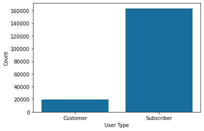

```python
base_color = sb.color_palette('colorblind')[0]
sb.countplot(data=df, x='user_type', color = base_color );
plt.xlabel('User Type');
plt.ylabel('Count');
```

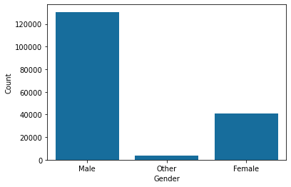

```python
sb.countplot(data=df, x='member_gender', color=base_color);
plt.xlabel('Gender');
plt.ylabel('Count');
```

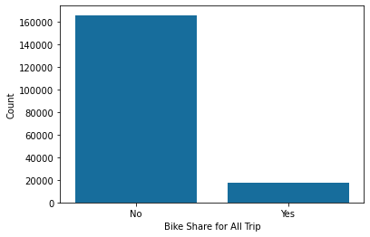

```python
sb.countplot(data=df, x='bike_share_for_all_trip', color=base_color);
plt.xlabel('Bike Share for All Trip');
plt.ylabel('Count');
```

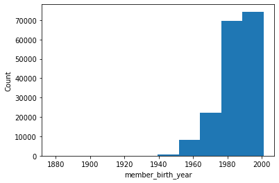

```python
plt.hist(data=df, x='member_birth_year')
plt.xlabel('member_birth_year')
plt.ylabel('Count');
```

most memebers were born between 1970-2000

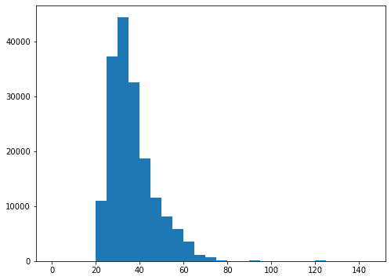

```python
# plot the distribution of members' age, visually examine for some outliers over 100 yrs old
plt.figure(figsize=[8, 6])
bins = np.arange(0, df['member_age'].max()+5, 5)
plt.hist(df['member_age'].dropna(), bins=bins);
```

Most members were around 20 to 50 years old

```python
 df['duration_min']=df.duration_sec/60
```

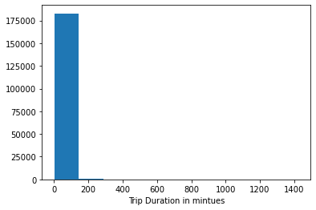

```python
plt.hist(data=df, x='duration_min');
plt.xlabel('Trip Duration in mintues');
```

the majority of the rides were quite short (within 200 mins).

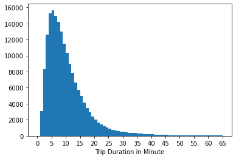

```python
bins = np.arange(0, 66, 1)
ticks = np.arange(0, 66, 5)
plt.hist(data=df, x='duration_min', bins=bins);
plt.xticks(ticks, ticks);
plt.xlabel('Trip Duration in Minute');
```

##### Bivariate Exploration

```python
df['user_type'] = df['user_type'].astype('category')
df['member_gender'] = df['member_gender'].astype('category')
```

```python
df = df.query('duration_min <= 66')
df.info(null_counts=True)
```

```
<class 'pandas.core.frame.DataFrame'>
Int64Index: 181899 entries, 4 to 183411
Data columns (total 18 columns):
 #   Column                   Non-Null Count   Dtype
---  ------                   --------------   -----
 0   duration_sec             181899 non-null  int64
 1   start_time               181899 non-null  object
 2   end_time                 181899 non-null  object
 3   start_station_id         181704 non-null  float64
 4   start_station_name       181704 non-null  object
 5   start_station_latitude   181899 non-null  float64
 6   start_station_longitude  181899 non-null  float64
 7   end_station_id           181704 non-null  float64
 8   end_station_name         181704 non-null  object
 9   end_station_latitude     181899 non-null  float64
 10  end_station_longitude    181899 non-null  float64
 11  bike_id                  181899 non-null  int64
 12  user_type                181899 non-null  category
 13  member_birth_year        173928 non-null  float64
 14  member_gender            173928 non-null  category
 15  bike_share_for_all_trip  181899 non-null  object
 16  member_age               173928 non-null  float64
 17  duration_min             181899 non-null  float64
dtypes: category(2), float64(9), int64(2), object(5)
memory usage: 23.9+ MB
```

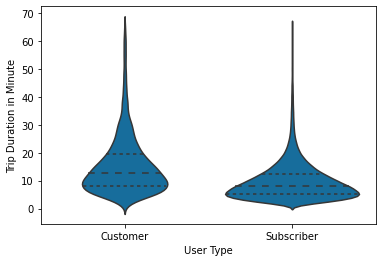

```python
sb.violinplot(data=df, x='user_type', y='duration_min', color=base_color, inner='quartile');
plt.xlabel('User Type');
plt.ylabel('Trip Duration in Minute');
```

The trip duration distribution is much narrower for subscribers compared to casual riders on the shorter/quicker trip end overall.

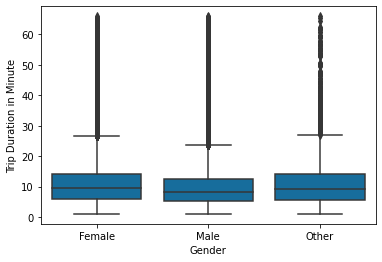

```python
sb.boxplot(data=df, x='member_gender', y='duration_min', color=base_color);
plt.xlabel('Gender');
plt.ylabel('Trip Duration in Minute');
```

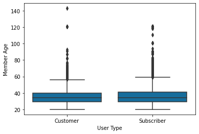

```python
sb.boxplot(data=df, x='user_type', y='member_age', color=base_color);
plt.xlabel('User Type');
plt.ylabel('Member Age');
```

#### Multivariate Exploration

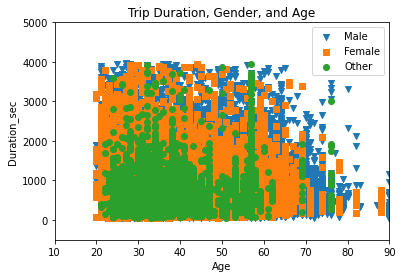

```python
gender_mark = [['Male', 'v'],['Female', 's'],['Other', 'o']]

for gender, marker in gender_mark:
    df_gender = df[df['member_gender'] == gender]
    plt.scatter((2021-df_gender['member_birth_year']), df_gender['duration_sec'], marker = marker, alpha= 1)
plt.legend(['Male','Female','Other'])
plt.axis([10, 90, -500, 5000 ])
plt.title('Trip Duration, Gender, and Age')
plt.xlabel('Age')
plt.ylabel('Duration_sec')
plt.show()
```

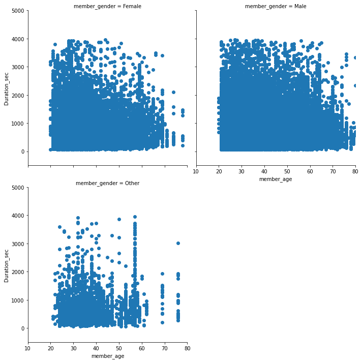

```python
gender = sb.FacetGrid(data = df, col = 'member_gender', col_wrap = 2, size = 5,
                 xlim = [10, 80], ylim = [-500, 5000])
gender.map(plt.scatter, 'member_age', 'duration_sec', alpha= 1)


gender.set_xlabels('member_age')
gender.set_ylabels('Duration_sec')
plt.show();
```

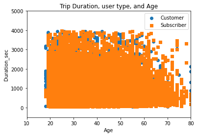

```python
usertype_mark = [['Customer', 'o'],['Subscriber', 's']]

for utype, marker in usertype_mark:
    df_utype = df[df['user_type'] == utype]
    plt.scatter((2019 - df_utype['member_birth_year']), df_utype['duration_sec'], marker = marker, alpha= 1)
plt.legend(['Customer','Subscriber'])
plt.axis([10, 80, -500, 5000 ])
plt.title('Trip Duration, user type, and Age')
plt.xlabel('Age')
plt.ylabel('Duration_sec')
plt.show()
```

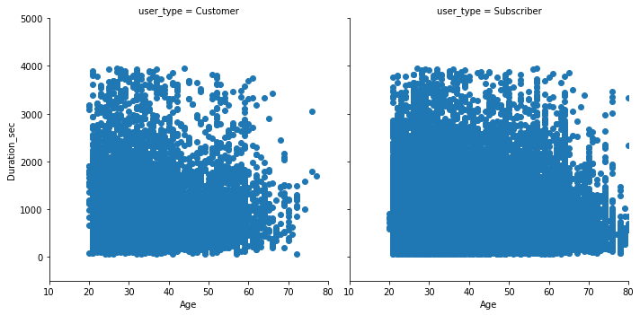

```python
user_type = sb.FacetGrid(data = df, col = 'user_type', col_wrap = 2, size = 5,
                 xlim = [10, 80], ylim = [-500, 5000])
user_type.map(plt.scatter, 'member_age', 'duration_sec', alpha= 1)

user_type.set_xlabels('Age')
user_type.set_ylabels('Duration_sec')
plt.show()
```

For the age, duration, and user type, both Customer and Subscriber are showing similar trends for age and trip duration

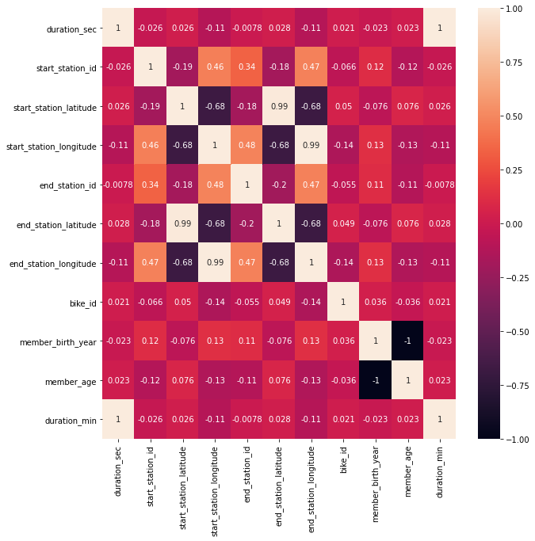

```python
corrMatrix = df.corr()
fig,ax = plt.subplots(figsize=(10,10))
sb.heatmap(corrMatrix, annot=True ,ax=ax)
plt.show()
```

```python
!jupyter slide_deck_presentation.ipynb --toslides --template output-toggle.tpl--post serve
```

[output not shown]